# Clustering and categorization

Peter Ralph

26 February 2018 – Advanced Biological Statistics

# Clusters in expression space

## A conceptual model

Let’s build a *conceptual* model for descriptive analysis of “mixture” expression data.

**Data:** expression data from tissue samples that consist of various *mixtures* of different cell types.

**Goal:** identify shared coexpression patterns corresponding to *cell type*.

*Similar situations:* identify different developmental stages from whole-organism expression; common community structures from metagenomic data.

1. Each cell type has a typical set of *mean* expression levels.
2. Each sample is composed of a mixture of cell types, defined by the proportions that come from each type.
3. Mean expression levels differ between cell types for only some of the genes.
4. Some samples are *noisier* than others.

**Assume** the same amount of sequencing of each sample.

1. Mean expression by cell type.
2. Cell type proportions by sample.
1. $x_{kj}$ : Mean expression of gene $j$ in cell type $k$.
2. $w_{ik}$ : Proportion of sample $i$ of cell type $k$.

$Z_{ij}$ : expression level in sample $i$ of gene $j$.

$$\begin{aligned}
Z_{ij} \approx \sum_{k=1}^K w_{ik} x_{kj} .
\end{aligned}$$

1. Mean expression by cell type.
2. Cell type proportions by sample.
3. Mean expression levels differ between cell types for only some of the genes.
4. Some samples are *noisier* than others.

$Z_{ij}$ : expression level in sample $i$ of gene $j$.

$$\begin{aligned}
Z_{ij} \approx \sum_{k=1}^K w_{ik} x_{kj} .
\end{aligned}$$

3. $y_j$, $\eta_j$ : mean and SD of expression of gene $j$ across *all* cell types; shrink $x_{kj}$ towards $y_j$.
4. *(omit this)*

```
data {
  int N; // # samples
  int L; // # genes
  int K; // # cell types
  int Z[N,L];
}
```

```
parameters {
  matrix<lower=0>[L,K] x;
  vector[L] y;
  simplex[K] w[N];
  vector<lower=0>[L] eta;
  vector<lower=0>[K] alpha;
  real<lower=0> d_alpha;
}
```

```
model {
  for (i in 1:N) {
      Z[i] ~ poisson(eta .* (x * w[i]));
      w[i] ~ dirichlet(d_alpha * alpha);
  }
  for (j in 1:K)
      { x[,j] ~ normal(y ./ eta, 1); }
  y ~ normal(0, 20);
  alpha ~ normal(0, 1);
  d_alpha ~ exponential(0.2);
  eta ~ cauchy(0, 10);
}
```

1. $x_{kj}$ : Mean expression of gene $j$ in cell type $k$.
2. $w_{ik}$ : Proportion of sample $i$ of cell type $k$.

$$\begin{aligned}
Z_{ij} \approx \sum_k w_{ik} x_{kj} .
\end{aligned}$$

3. $y_j$, $\eta_j$ : mean and SD of expression of gene $j$ across *all* cell types; shrink $x_{kj}$ towards $y_j$.

## Testing: compiles?

```r
nmf_model <- stan_model(model_code=nmf_block)
```

## Testing: runs?

```r
sampling(nmf_model,
         data=list(N=10,
                   L=5,
                   K=2,
                   Z=matrix(rpois(50, 100), ncol=5)),
         chains=1, iter=100)
```

[output not shown]

```
## Inference for Stan model: 027c9a0b92082dc735bfb6350861f7ee.
## 1 chains, each with iter=100; warmup=50; thin=1;
## post-warmup draws per chain=50, total post-warmup draws=50.
##
##              mean se_mean    sd     2.5%      25%      50%      75%
## x[1,1]       1.24    0.11  0.75     0.16     0.74     1.11     1.56
## x[1,2]       1.55    0.12  0.87     0.37     0.98     1.47     2.03
## x[2,1]       0.94    0.16  0.69     0.09     0.40     0.82     1.26
## x[2,2]       1.19    0.08  0.60     0.33     0.79     1.10     1.47
## x[3,1]       1.00    0.10  0.68     0.10     0.46     0.90     1.42
## x[3,2]       1.22    0.10  0.71     0.28     0.72     1.15     1.52
## x[4,1]       1.01    0.13  0.63     0.04     0.61     0.90     1.38
## x[4,2]       1.30    0.09  0.61     0.43     0.95     1.20     1.44
## x[5,1]       1.14    0.08  0.58     0.20     0.76     1.02     1.56
## x[5,2]       1.32    0.09  0.62     0.28     0.86     1.25     1.71
## y[1]        17.72    5.98 16.01    -4.92     4.17    14.21    29.40
## y[2]        -0.24    6.73 15.63   -29.54    -9.72     3.55     7.78
## y[3]         1.98   12.59 20.71   -28.37   -19.01     7.52    19.56
## y[4]         7.92    5.13 13.46   -15.87    -3.00     7.16    19.72
## y[5]         4.64    1.49  7.82   -12.16     1.29     4.61     7.32
## w[1,1]       0.30    0.05  0.25     0.03     0.11     0.22     0.40
## w[1,2]       0.70    0.05  0.25     0.13     0.60     0.78     0.89
## w[2,1]       0.29    0.05  0.23     0.04     0.13     0.22     0.32
## w[2,2]       0.71    0.05  0.23     0.19     0.68     0.78     0.87
## w[3,1]       0.31    0.05  0.24     0.02     0.12     0.23     0.44
## w[3,2]       0.69    0.05  0.24     0.17     0.56     0.77     0.88
## w[4,1]       0.32    0.05  0.24     0.04     0.14     0.27     0.44
## w[4,2]       0.68    0.05  0.24     0.16     0.56     0.73     0.86
## w[5,1]       0.30    0.06  0.27     0.02     0.08     0.19     0.45
## w[5,2]       0.70    0.06  0.27     0.11     0.55     0.81     0.92
## w[6,1]       0.31    0.05  0.24     0.03     0.11     0.24     0.43
## w[6,2]       0.69    0.05  0.24     0.12     0.57     0.76     0.89
## w[7,1]       0.30    0.05  0.23     0.02     0.11     0.24     0.43
## w[7,2]       0.70    0.05  0.23     0.21     0.57     0.76     0.89
## w[8,1]       0.32    0.04  0.23     0.05     0.14     0.25     0.43
## w[8,2]       0.68    0.04  0.23     0.17     0.57     0.75     0.86
## w[9,1]       0.29    0.06  0.28     0.01     0.09     0.17     0.47
## w[9,2]       0.71    0.06  0.28     0.10     0.53     0.83     0.91
## w[10,1]      0.30    0.05  0.24     0.04     0.10     0.20     0.43
## w[10,2]      0.70    0.05  0.24     0.17     0.57     0.80     0.90
```

[output cut: 44 more lines]

```
## w[10,2]      0.96    23 0.98
## eta[1]     254.81    41 1.01
## eta[2]     301.68    35 1.00
## eta[3]     243.57    47 1.07
## eta[4]     186.39    50 0.99
## eta[5]     160.69    40 0.98
## alpha[1]     2.16    21 0.98
## alpha[2]     2.62    50 0.98
## d_alpha     27.86    45 1.03
## lp__     18260.60    11 0.98
##
## Samples were drawn using NUTS(diag_e) at Wed Mar  7 10:44:56 2018.
## For each parameter, n_eff is a crude measure of effective sample size,
## and Rhat is the potential scale reduction factor on split chains (at
## convergence, Rhat=1).
```

# Nonnegative matrix factorization

## … aka “NMF”

We are *decomposing* $Z$ into the product of two lower-dimensional, nonnegative factors:

$$\begin{aligned}
Z_{ij} &\approx \sum_k w_{ik} x_{kj} \\
w_{ik} &\ge 0 \\
x_{kj} &\ge 0 .
\end{aligned}$$

This is like PCA, but sometimes more *interpretable*.

# Stochastic minute

## the Dirichlet distribution

A random set of $k$ *proportions* $0 \le P_i \le 1$ has a $\Dirichlet(\alpha_1, \ldots, \alpha_k)$ if it has probability density
$$\begin{aligned}
\frac{1}{B(\alpha)} \prod_{i=1}^k p_i^{\alpha_i}
\end{aligned}$$
over the set of possible values
$$\begin{aligned}
P_1 + \cdots + P_k = 1 .
\end{aligned}$$

1. This is useful as a prior on *proportions*.
2. This generalized the Beta: if $X \sim \Beta(a, b)$ then $(X, 1-X) \sim \Dirichlet(a, b)$.
3. Marginal distributions are Beta distributed: $P_i \sim \Beta(\alpha_i, \sum_{j=1}^k \alpha_j - \alpha_i)$.
4. If $X_i \sim \Exp(\alpha_i)$, and
   $$\begin{aligned}
   P_i = X_i / \sum_{j=1}^k X_j
   \end{aligned}$$
   then $P \sim \Dirichlet(\alpha)$.

## “Simplex” parameters

“The $k$-simplex” is the set of *proportions*, i.e., nonnegative numbers $p$ satisfying
$$\begin{aligned}
p_1 + \cdots p_k = 1 .
\end{aligned}$$

```
parameters {
    simplex[K] w[N];
}
model {
    w ~ dirichlet(d_alpha * alpha);
}
```

# Simulate data

## Outline

1. How many cell types? *five*
2. How many genes? *one thousand*
3. How many samples? *one hundred*
4. How much noise in expression? *Mean expression per gene are $\mu \sim \Exp(1/100)$; expression per sample is $\Poisson(m)$, where $m$ is truncated $\Normal(\mu, \sigma \mu)$, and $\sigma$ is around 1.*
5. How many genes distinguish cell types, and by how much relative to expression? *Ten percent of genes, and a gene with mean expression $\mu$ differs between cell types by about $\mu/2$: means by cell type are $\mu \times \log\Normal(0, 1)$.*
6. How many “noisy” genes? How many “noisy” samples? *Two percent of each.*

# An easy case

## Parameters:

```r
ntypes <- 3
ngenes <- 1000
nsamples <- 1000
ninf <- 0.6 * ngenes # number of informative genes
```

Determine expression profiles per cell type

```r
mu <- rexp(ngenes, .01)
# copy mu into five columns
type_mu <- do.call(cbind, list(mu)[rep(1,ntypes)])

# simulate how differnt mu is across cell types
diff_sigma <- matrix(rlnorm(ntypes * ninf, log(0.5), 1), ncol=ntypes)
type_mu[1:ninf,] <- type_mu[1:ninf,] * diff_sigma

m_list <- lapply(1:ntypes, function (ct) {
                    matrix(pmax(0, rnorm(ngenes*nsamples,
                                         type_mu[,ct], type_mu[,ct])),
                           ncol=ngenes, byrow=TRUE) })
```

Simulate proportions per sample, and construct expected expression levels

```r
# simulate proportions per sample
w <- matrix( rexp(nsamples*ntypes), ncol=ntypes)
w <- sweep(w, 1, rowSums(w), "/")
stopifnot(all(abs(rowSums(w) - 1) < 1e-15))

# construct expected expression levels:
m <- matrix(0, nrow=nsamples, ncol=ngenes)
for (ct in 1:ntypes) {
    m <- m + (w[,ct] * m_list[[ct]])
}
```

```r
# simulate expression
Z <- matrix(rpois(length(m), m), ncol=ncol(m))

# add noisy indivs, genes??
```

## Point estimates with `optimizing`

```r
system.time(nmf_optim <- optimizing(nmf_model,
                                    data=list(N=nsamples,
                                              L=ngenes,
                                              K=ntypes,
                                              Z=Z)))
```

```
## Initial log joint probability = 2.58746e+07
## Error evaluating model log probability: Non-finite gradient.
## Error evaluating model log probability: Non-finite gradient.
##
## Optimization terminated normally:
##   Convergence detected: relative gradient magnitude is below tolerance
```

```
##    user  system elapsed
## 162.735   0.020 162.780
```

## Can we infer mixture proportions?

```r
results <- list(x=nmf_optim$par[grepl("^x", names(nmf_optim$par))],
                y=nmf_optim$par[grepl("^y", names(nmf_optim$par))],
                w=nmf_optim$par[grepl("^w", names(nmf_optim$par))],
                eta=nmf_optim$par[grepl("^eta", names(nmf_optim$par))],
                alpha=nmf_optim$par[grepl("^alpha", names(nmf_optim$par))],
                d_alpha=nmf_optim$par[grepl("^d_alpha", names(nmf_optim$par))])
dim(results$x) <- c(ngenes, ntypes)
dim(results$w) <- c(nsamples, ntypes)

cor(results$w, w)
```

```
##            [,1]       [,2]       [,3]
## [1,] -0.5808138  0.9782592 -0.4166005
## [2,] -0.4704923 -0.4772288  0.9730529
## [3,]  0.9826326 -0.5158866 -0.4709883
```

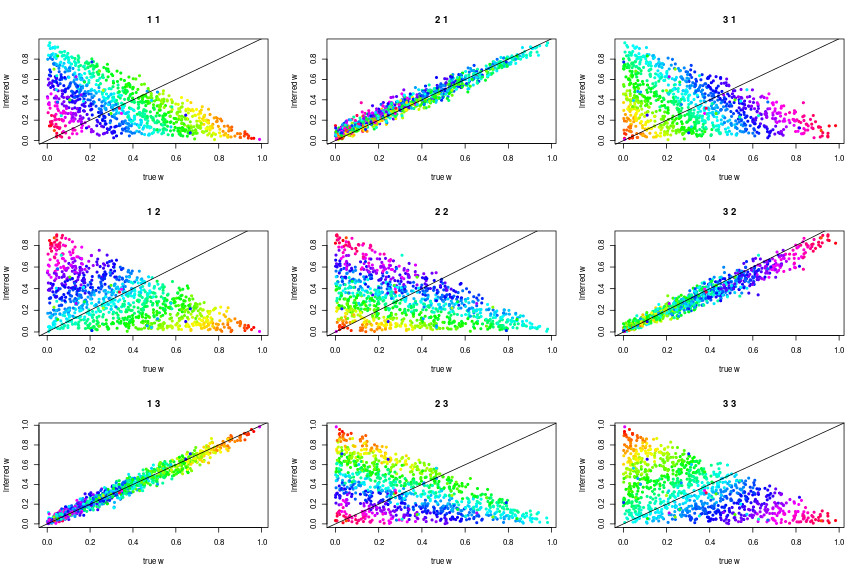

The mean absolute error in inference of mixture proportions ($w$) is 0.0423191.

## Can we infer expression profiles?

```r
cor(results$x, type_mu)
```

```
##             [,1]        [,2]       [,3]
## [1,] -0.09646527  0.24097595 -0.1065245
## [2,] -0.09615290 -0.10846957  0.2138270
## [3,]  0.28938213 -0.08564512 -0.1106754
```

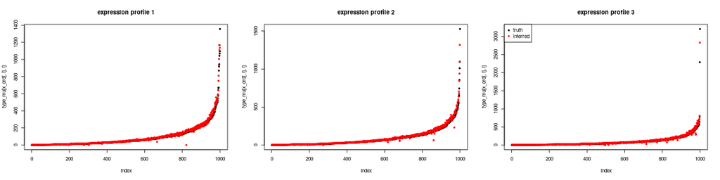

```r
xij <- apply(cor(results$x, type_mu), 2, which.max)
x_ord <- apply(type_mu, 2, order)
layout(t(1:ntypes))
for (i in 1:ntypes) {
    plot(type_mu[x_ord[,i],i], pch=20,
         main=paste("expression profile", i))
    points((results$eta * results$x[,xij[i]])[x_ord[,i]], pch=20, col='red')
}
legend("topleft", pch=20, col=c("black", "red"),
       legend=c("truth", "inferred"))
```

# A harder case

## Parameters:

```r
ntypes <- 5
ngenes <- 1000
nsamples <- 100
ninf <- 0.1 * ngenes # number of informative genes
```

Determine expression profiles per cell type

```r
mu <- rexp(ngenes, .01)
# copy mu into five columns
type_mu <- do.call(cbind, list(mu)[rep(1,ntypes)])

# simulate how differnt mu is across cell types
diff_sigma <- matrix(rlnorm(ntypes * ninf, log(0.5), 1), ncol=ntypes)
type_mu[1:ninf,] <- type_mu[1:ninf,] * diff_sigma

m_list <- lapply(1:ntypes, function (ct) {
                    matrix(pmax(0, rnorm(ngenes*nsamples,
                                         type_mu[,ct], type_mu[,ct])),
                           ncol=ngenes, byrow=TRUE) })
```

Simulate proportions per sample, and construct expected expression levels

```r
# simulate proportions per sample
w <- matrix( rexp(nsamples*ntypes), ncol=ntypes)
w <- sweep(w, 1, rowSums(w), "/")
stopifnot(all(abs(rowSums(w) - 1) < 1e-15))

# construct expected expression levels:
m <- matrix(0, nrow=nsamples, ncol=ngenes)
for (ct in 1:ntypes) {
    m <- m + (w[,ct] * m_list[[ct]])
}
```

```r
# simulate expression
Z <- matrix(rpois(length(m), m), ncol=ncol(m))

# add noisy indivs, genes??
```

## Point estimates with `optimizing`

```r
system.time(nmf_optim <- optimizing(nmf_model,
                                    data=list(N=nsamples,
                                              L=ngenes,
                                              K=ntypes,
                                              Z=Z)))
```

```
## Initial log joint probability = 3.22418e+06
## Optimization terminated normally:
##   Maximum number of iterations hit, may not be at an optima
```

```
##    user  system elapsed
##  22.106   0.011  22.127
```

## Can we infer mixture proportions?

```r
results <- list(x=nmf_optim$par[grepl("^x", names(nmf_optim$par))],
                y=nmf_optim$par[grepl("^y", names(nmf_optim$par))],
                w=nmf_optim$par[grepl("^w", names(nmf_optim$par))],
                eta=nmf_optim$par[grepl("^eta", names(nmf_optim$par))],
                alpha=nmf_optim$par[grepl("^alpha", names(nmf_optim$par))],
                d_alpha=nmf_optim$par[grepl("^d_alpha", names(nmf_optim$par))])
dim(results$x) <- c(ngenes, ntypes)
dim(results$w) <- c(nsamples, ntypes)

cor(results$w, w)
```

```
##             [,1]        [,2]        [,3]        [,4]       [,5]
## [1,]  0.70346443 -0.35350986  0.01131823  0.19682506 -0.4302360
## [2,] -0.52692824 -0.03719675  0.09822368  0.11374785  0.3348279
## [3,] -0.02538077  0.52348238 -0.11243521 -0.25411249 -0.1954045
## [4,] -0.16689208  0.40134261 -0.13149467  0.04997887 -0.1598633
## [5,] -0.25402853 -0.34108062  0.10875600 -0.22951899  0.6125462
```

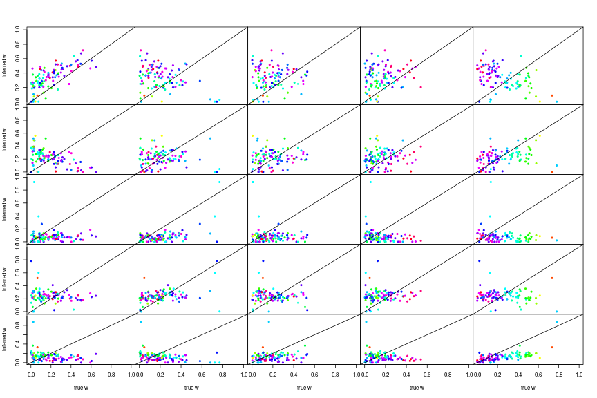

The mean absolute error in inference of mixture proportions ($w$) is 0.1560075.

## Can we infer expression profiles?

```r
cor(results$x, type_mu)
```

```
##              [,1]         [,2]        [,3]        [,4]        [,5]
## [1,]  0.003493925 -0.100144726 -0.06501465 -0.00741866 -0.10650807
## [2,] -0.102344361 -0.076685361 -0.04067808 -0.04602893 -0.04144020
## [3,] -0.002324807  0.039969510 -0.02602720 -0.02708119 -0.03212653
## [4,] -0.036106205 -0.008097775 -0.02712279 -0.01015633 -0.03046783
## [5,] -0.020074330 -0.019037972  0.02745353 -0.01491372  0.05433943
```

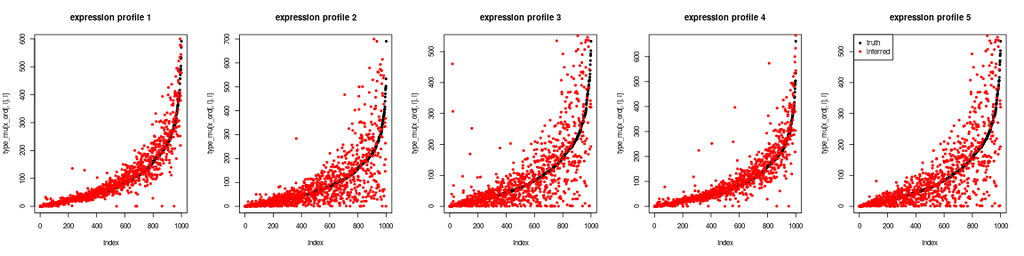

```r
xij <- apply(cor(results$x, type_mu), 2, which.max)
x_ord <- apply(type_mu, 2, order)
layout(t(1:ntypes))
for (i in 1:ntypes) {
    plot(type_mu[x_ord[,i],i], pch=20,
         main=paste("expression profile", i))
    points((results$eta * results$x[,xij[i]])[x_ord[,i]], pch=20, col='red')
}
legend("topleft", pch=20, col=c("black", "red"),
       legend=c("truth", "inferred"))
```